# Airbnb New User Bookings

### January, 2017

### This project is made for BDA 507 Intro to Programming for Big Data (Python) Course.

# A. Introduction

## About the Data

"The data set l chose is Airbnb Users data set that is offered for the recruiting competition. Airbnb New User Bookings data set is represented at Kaggle.com by Airbnb that is community marketplace for people to list, discover, and book unique accommodations around the world. The data set includes a list of users along with their demographics, web session records, and some summary statistics. All the users in this dataset are from the USA. "There are 12 possible outcomes of the destination country: 'US', 'FR', 'CA', 'GB', 'ES', 'IT', 'PT', 'NL','DE', 'AU', 'NDF' (no destination found), and 'other'. The training and test sets are split by dates. In the test set, you will predict all the new users with first activities after 7/1/2014 (note: this is updated on 12/5/15 when the competition restarted). In the sessions dataset, the data only dates back to 1/1/2014, while the users dataset dates back to 2010.

## File Descriptions

- train_users.csv - the training set of users
- test_users.csv - the test set of users
  - id: user id
  - date_account_created: the date of account creation
  - timestamp_first_active: timestamp of the first activity, note that it can be earlier than date_account_created or date_first_booking because a user can search before signing up
  - date_first_booking: date of first booking
  - gender
  - age
  - signup_method
  - signup_flow: the page a user came to signup up from
  - language: international language preference
  - affiliate_channel: what kind of paid marketing
  - affiliate_provider: where the marketing is e.g. google, craigslist, other
  - first_affiliate_tracked: whats the first marketing the user interacted with before the signing up
  - signup_app
  - first_device_type
  - first_browser
  - country_destination: this is the target variable you are to predict
- sessions.csv - web sessions log for users
  - user_id: to be joined with the column 'id' in users table
  - action
  - action_type
  - action_detail
  - device_type
  - secs_elapsed
- countries.csv - summary statistics of destination countries in this dataset and their locations
  - AU- Australia
  - CA- Canada
  - DE- Germany
  - ES- Spain
  - FR- France
  - GB- United Kingdom
  - IT- Italy
  - NL- Netherlands
  - PT- Portugal
  - US- United States
- age_gender_bkts.csv - summary statistics of users' age group, gender, country of destination
- sample_submission.csv - correct format for submitting your predictions""[1]

## More about Airbnb

"Airbnb is an online marketplace and hospitality service, enabling people to lease or rent short-term lodging including vacation rentals, apartment rentals, homestays, hostel beds, or hotel rooms. The company does not own any lodging; it is merely a broker and receives percentage service fees (commissions) from both guests and hosts in conjunction with every booking. It has over 3,000,000 lodging listings in 65,000 cities and 191 countries, and the cost of lodging is set by the host.

## How it works

Airbnb can be accessed via either the Airbnb websites or mobile applications for iOS, Apple Watch, and Android. Registration and account creation is free. On each booking, the company charges guests a 6%-12% guest services fee and charges hosts a 3%-5% host service fee. Hosts can also offer "experiences", such as excursions, to guests for an additional charge, of which Airbnb takes 20% as a commission.

Users can search for lodging using a variety of filters including lodging type, dates, location, and price. Before booking, users must provide a valid name, email address, telephone number, photo, payment information, and, if required by the host, a scan of a government-issued ID. Guests also are required to agree to any house rules of the host." [2]

## Purpose and Objectives of the Project

This data is served for a Kaggle competition the aim was to predict for which country a new user will make his or her first booking. It can be suggested that Airbnb intends to know the journeys that the users who book have. It is possible to derive personas from the data. Each journey types help create a persona. In this way, the company invests its resources on the right users with the right ways. For example, if the users who book by using android mostly, the company may want to prioritize the topic of consumer experience on android. If insight can be gathered from the data, it leads action plans for the company.

As a hobby, I follow shared economy platforms and the developments in this area. Airbnb is one of them. Moreover, I like the idea of connecting people/cultures. 2 years ago I have watched [this video](https://www.youtube.com/watch?v=BpAdyFdE3-c) that touched me as a person who lived in Berlin and put freedom first. I like the mission of Airbnb. Therefore, I chose to explore the Airbnb dataset. I wanted to comprehend the meaning of the dataset, find the differences and similarities in the preferences of subgroups. I hoped to find a meaningful insight. There might be an insight from the way people come to contact with Airbnb.

# B. DESCRIPTIVE STATISTICS

## Data Exporting

```python
import pandas as pd
import numpy as np
```

```python
import os
os.chdir("C:\\Users\\bengisu\\Documents")

users = pd.read_csv("train_users_22.csv") # getting airbnb csv files as a DataFrame
```

## Data Exploration

```python
print(users.head())
```

```
           id date_account_created  timestamp_first_active date_first_booking  \
0  gxn3p5htnn           2010-06-28          20090319043255                NaN
1  820tgsjxq7           2011-05-25          20090523174809                NaN
2  4ft3gnwmtx           2010-09-28          20090609231247         2010-08-02
3  bjjt8pjhuk           2011-12-05          20091031060129         2012-09-08
4  87mebub9p4           2010-09-14          20091208061105         2010-02-18

      gender   age signup_method  signup_flow language affiliate_channel  \
0  -unknown-   NaN      facebook            0       en            direct
1       MALE  38.0      facebook            0       en               seo
2     FEMALE  56.0         basic            3       en            direct
3     FEMALE  42.0      facebook            0       en            direct
4  -unknown-  41.0         basic            0       en            direct

  affiliate_provider first_affiliate_tracked signup_app first_device_type  \
0             direct               untracked        Web       Mac Desktop
1             google               untracked        Web       Mac Desktop
2             direct               untracked        Web   Windows Desktop
3             direct               untracked        Web       Mac Desktop
4             direct               untracked        Web       Mac Desktop

  first_browser country_destination
0        Chrome                 NDF
1        Chrome                 NDF
2            IE                  US
3       Firefox               other
4        Chrome                  US
```

At the first sight, we see the titles of the data set: id date_account_created, timestamp_first_active, date_first_booking , gender, age, signup_method , signup_flow language, affiliate_channel, affiliate_provider, first_affiliate_tracked, signup_app, first_device_type, first_browser country_destination. Moreover, we get the clue about missing and non-defined variables.

```python
print(users.shape)  #checking the shape of dataframe
print(users.tail())
```

```
(213451, 16)
                id date_account_created  timestamp_first_active  \
213446  zxodksqpep           2014-06-30          20140630235636
213447  mhewnxesx9           2014-06-30          20140630235719
213448  6o3arsjbb4           2014-06-30          20140630235754
213449  jh95kwisub           2014-06-30          20140630235822
213450  nw9fwlyb5f           2014-06-30          20140630235824

       date_first_booking     gender   age signup_method  signup_flow  \
213446                NaN       MALE  32.0         basic            0
213447                NaN  -unknown-   NaN         basic            0
213448                NaN  -unknown-  32.0         basic            0
213449                NaN  -unknown-   NaN         basic           25
213450                NaN  -unknown-   NaN         basic           25

       language affiliate_channel affiliate_provider first_affiliate_tracked  \
213446       en         sem-brand             google                     omg
213447       en            direct             direct                  linked
213448       en            direct             direct               untracked
213449       en             other              other           tracked-other
213450       en            direct             direct               untracked

       signup_app first_device_type  first_browser country_destination
213446        Web       Mac Desktop         Safari                 NDF
213447        Web   Windows Desktop         Chrome                 NDF
213448        Web       Mac Desktop        Firefox                 NDF
213449        iOS            iPhone  Mobile Safari                 NDF
213450        iOS            iPhone      -unknown-                 NDF
```

```python
print(users.dtypes)
```

```
id                          object
date_account_created        object
timestamp_first_active       int64
date_first_booking          object
gender                      object
age                        float64
signup_method               object
signup_flow                  int64
language                    object
affiliate_channel           object
affiliate_provider          object
first_affiliate_tracked     object
signup_app                  object
first_device_type           object
first_browser               object
country_destination         object
dtype: object
```

Most of the features are objects.

```python
print(users.describe()) # checking the basic statistics of the features.
```

```
       timestamp_first_active            age    signup_flow
count            2.134510e+05  125461.000000  213451.000000
mean             2.013085e+13      49.668335       3.267387
std              9.253717e+09     155.666612       7.637707
min              2.009032e+13       1.000000       0.000000
25%              2.012123e+13      28.000000       0.000000
50%              2.013091e+13      34.000000       0.000000
75%              2.014031e+13      43.000000       0.000000
max              2.014063e+13    2014.000000      25.000000
```

There are unrealistic numbers on age column.

## Dealing with Missing and Abnormal Variables

```python
users.dropna()  #deleting the nan variables
print(users.shape)  #checking shape of the data again
```

```
(213451, 16)
```

```python
c=users.duplicated('id')
print(sum(i for i in c if i == True))  #checking if there is dublicate ids
```

```
0
```

There is no dublicate id.

```python
import numpy as np

users.loc[users.age < 13, 'age'] = np.nan  #deleting the ages smaller than 13 and bigger than 70.
users.loc[users.age > 70, 'age'] = np.nan
```

```python
print(users.age.describe())
print(users.age.mode())
print(users.age.median())     #checking if the previous code works or not
```

```
count    121612.000000
mean         36.056820
std          10.771287
min          15.000000
25%          28.000000
50%          33.000000
75%          42.000000
max          70.000000
Name: age, dtype: float64
0    30.0
dtype: float64
33.0
```

Average age is 36. Mode is 30. Median is 33.

```python
users=users.dropna(axis=0, subset=['age'])  #deleting the nan variable

print(users.age.describe())  #checking if the previous code works or not
```

```
count    121612.000000
mean         36.056820
std          10.771287
min          15.000000
25%          28.000000
50%          33.000000
75%          42.000000
max          70.000000
Name: age, dtype: float64
```

There are unknown variables at gender feature so l wanted to convert them to nan.

```python
users.loc[users.gender=='-unknown-','gender'] = np.nan  #replacing the unknown as nan at gender
users.loc[users.gender=='OTHER','gender'] = np.nan

print(users.gender.head()) #checking the new gender column
print(users.gender.describe())
```

```
1      MALE
2    FEMALE
3    FEMALE
4       NaN
6    FEMALE
Name: gender, dtype: object
count     105456
unique         2
top       FEMALE
freq       56096
Name: gender, dtype: object
```

## Analyzing and Visualization

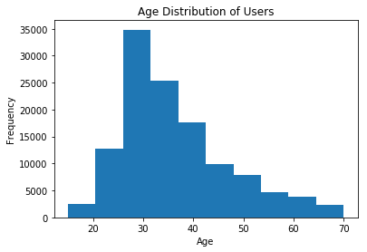

```python
#visualization of age
import matplotlib.pyplot as plt

users.age.plot('hist')
plt.xlabel('Age')
plt.title('Age Distribution of Users')
plt.show()
```

This histogram shows the ages of the users. You see on the right side that there are a few users whose ages are older than the other users. Most of the users are between 23 and 39 years old. A few users are older than 60 years.

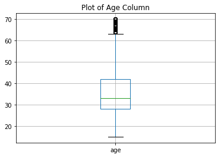

```python
users.boxplot(column='age') #looking at the ages with box plot
plt.title('Plot of Age Column')
plt.show()
```

As can be seen from the box plot, the ages older than 62 years old are outliers. The lower limit of the ages is 15 years old. Median age is 33.

It is better to group to ages in order to visualize the age feature easily.

```python
mean=users.age.mean()
std=users.age.std()

young= mean-std
old=mean+std

agelabel = []

for i in users['age']:
    if i < (mean-std):
        agelabel.append('Young')
    elif i < (mean + std):
        agelabel.append('Mature')
    elif i > (mean + std):
        agelabel.append('Old')
    else:
        agelabel.append('None')


users['agelabel'] = agelabel             #creating a column from the list
```

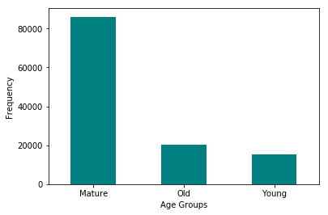

```python
users.agelabel.value_counts(dropna=True).plot(kind='bar', rot=0, color='teal')
plt.xlabel('Age Groups')
plt.ylabel('Frequency')
plt.show()
```

When ages are labeled, it is seen that there are more mature users than others.

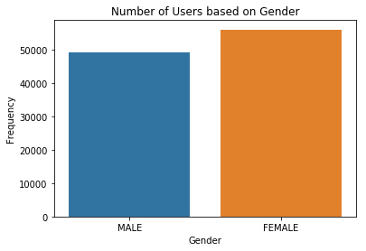

```python
import seaborn as sns

sns.countplot(x="gender", data=users)    #visualization of female and male users
plt.xlabel('Gender')
plt.ylabel('Frequency')
plt.title('Number of Users based on Gender')
plt.show()
```

There are more female users than male users.

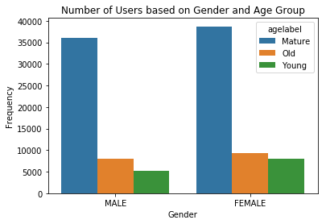

```python
import matplotlib.pyplot as plt

sns.countplot(x='gender', hue = 'agelabel',data=users)
plt.xlabel('Gender')
plt.ylabel('Frequency')
plt.title('Number of Users based on Gender and Age Group')
plt.show()
```

Female users are younger than male users.

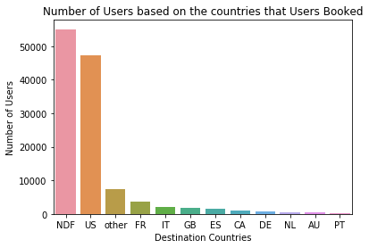

```python
sns.countplot(x="country_destination", data=users,order =users['country_destination'].value_counts().index)
plt.xlabel('Destination Countries')
plt.ylabel('Number of Users')
plt.title('Number of Users based on the countries that Users Booked')
plt.show()
```

As we remember all the users in this dataset are from the USA. It is assumed that the most of the users booked from Airbnb for the country trip. It is followed by France, Italy, United Kingdom.

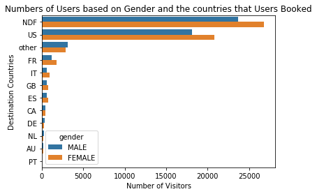

```python
sns.countplot(y='country_destination', hue="gender", data=users,order =users['country_destination'].value_counts().index)
plt.ylabel('Destination Countries')
plt.xlabel('Number of Visitors')
plt.title('Numbers of Users based on Gender and the countries that Users Booked')
plt.show()
```

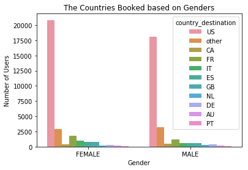

```python
sns.countplot(x='gender', hue = 'country_destination',data=users[users['country_destination'] != 'NDF'])
plt.xlabel('Gender')
plt.ylabel('Number of Users')
plt.title('The Countries Booked based on Genders')
plt.show()
```

Female users choose Italy more than male users do.

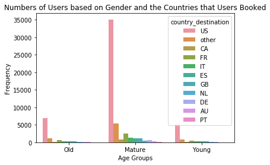

```python
sns.countplot(x='agelabel', hue = 'country_destination',data=users[users['country_destination'] != 'NDF'])
plt.xlabel('Age Groups')
plt.ylabel('Frequency')
plt.title('Numbers of Users based on Gender and the Countries that Users Booked')
plt.show()
```

Users who are from age group Mature book place from Europe more than other age groups.

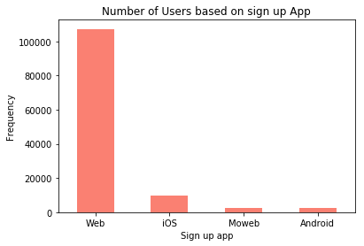

```python
users.signup_app.value_counts(dropna=True).plot(kind='bar', rot=0, color="salmon")
plt.xlabel('Sign up app')
plt.ylabel('Frequency')
plt.title('Number of Users based on sign up App')
plt.show()
```

Most of the users sign up on web browsers. It can be assumed that hey plan the accommodation in advance.

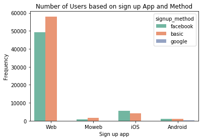

```python
sns.countplot(x='signup_app', hue = 'signup_method',data=users, palette="Set2")
plt.xlabel('Sign up app')
plt.ylabel('Frequency')
plt.title('Number of Users based on sign up App and Method')
plt.show()
```

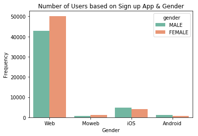

```python
sns.countplot(x='signup_app', hue = 'gender', palette="Set2",data=users)
plt.xlabel('Gender')
plt.ylabel('Frequency')
plt.title('Number of Users based on Sign up App & Gender')
plt.show()
```

[figure not shown]

```python
sns.countplot(x='gender', hue = 'signup_method',palette="Set2",data=users)
plt.xlabel('Gender')
plt.ylabel('Frequency')
plt.title('Number of Users based on Sign up Method & Gender')
plt.show()
```

```python
#There is a need to indicate the dates with month and year.

users['date_first_booking'] = pd.to_datetime(users['date_first_booking'])   #fb   #converting the date info to date type in pandas
users['date_account_created'] = pd.to_datetime(users['date_account_created']) #ac

print(users.info())  #checking the data set again
```

```
<class 'pandas.core.frame.DataFrame'>
Int64Index: 121612 entries, 1 to 213448
Data columns (total 17 columns):
id                         121612 non-null object
date_account_created       121612 non-null datetime64[ns]
timestamp_first_active     121612 non-null int64
date_first_booking         66571 non-null datetime64[ns]
gender                     105456 non-null object
age                        121612 non-null float64
signup_method              121612 non-null object
signup_flow                121612 non-null int64
language                   121612 non-null object
affiliate_channel          121612 non-null object
affiliate_provider         121612 non-null object
first_affiliate_tracked    119685 non-null object
signup_app                 121612 non-null object
first_device_type          121612 non-null object
first_browser              121612 non-null object
country_destination        121612 non-null object
agelabel                   121612 non-null object
dtypes: datetime64[ns](2), float64(1), int64(2), object(12)
memory usage: 21.7+ MB
None
```

```python
#group1 = users.groupby(pd.Grouper(key='date_first_booking', freq='1Y'))  #spliting by Year

fbtimeday=users['f1_day'] = pd.DatetimeIndex(users['date_first_booking']).day
fbtimeyear=users['f1_year'] = pd.DatetimeIndex(users['date_first_booking']).year
fbtimemonth=users['f1_month'] = pd.DatetimeIndex(users['date_first_booking']).month

print(fbtimeday.isnull().sum()) #checking the null values
users['f1_day']=users['f1_day'].dropna()
print(users['f1_day'].head(10))
```

```
55041
1      NaN
2      2.0
3      8.0
4     18.0
6      5.0
7     13.0
8     29.0
9      4.0
10     6.0
11     NaN
Name: f1_day, dtype: float64
```

```python
#having year,month,day time from date_account_created
actimeday=users['ac_day'] = pd.DatetimeIndex(users['date_account_created']).day
actimeyear=users['ac_year'] = pd.DatetimeIndex(users['date_account_created']).year
actimemonth=users['ac_month'] = pd.DatetimeIndex(users['date_account_created']).month

#creating a column that shows the same day booking
timebetween_fb_and_ac = pd.DatetimeIndex(users['date_first_booking']) - pd.DatetimeIndex(users['date_account_created'])
timebetween_fb_and_ac=timebetween_fb_and_ac.days
users["fb-ac"] = timebetween_fb_and_ac

users.loc[users["fb-ac"] < 0, 'fb-ac'] = "no-booking"
users["sameDayBooking"] = users["fb-ac"]==0

kk=users.loc[users["sameDayBooking"] == True, "sameDayBooking"].value_counts()   #counting the same day bookings
pp=users.loc[users["sameDayBooking"] == False, "sameDayBooking"].value_counts()

print(int(kk)/(int(kk)+int(pp)*100))
```

```
0.001360250474930721
```

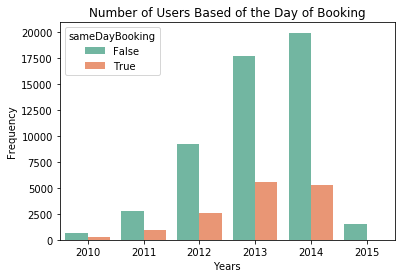

```python
sns.countplot(x="f1_year", hue=('sameDayBooking'),palette="Set2", data=users, order=[2010,2011,2012,2013,2014,2015])
plt.xlabel('Years')
plt.ylabel('Frequency')
plt.title('Number of Users Based of the Day of Booking')
plt.show()
```

As can be seen the from the graph, booking on the same day as registering is low across years. In 2015, there is no booking on the same day as registering.

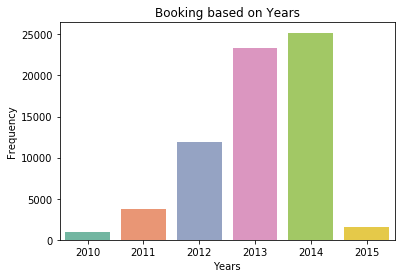

```python
sns.countplot(x="f1_year", data=users, palette="Set2", order=[2010,2011,2012,2013,2014,2015])
plt.xlabel('Years')
plt.ylabel('Frequency')
plt.title('Booking based on Years')
plt.show()
```

There are more users who book in 2013 and 2014 than other years.

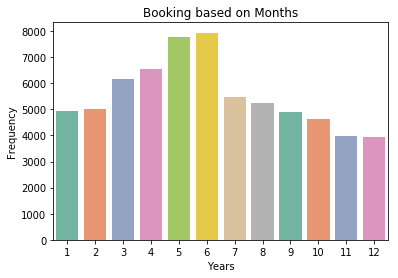

```python
sns.countplot(x="f1_month", data=users, palette="Set2",order=[1,2, 3, 4, 5, 6, 7, 8, 9, 10, 11, 12])
plt.xlabel('Years')
plt.ylabel('Frequency')
plt.title('Booking based on Months')
plt.show()
```

There are more users who book in April, May, and June than other months. Users start to plan their summer holidays from March.

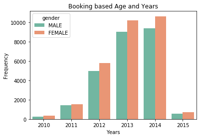

```python
sns.countplot(x="f1_year",hue="gender", data=users, palette="Set2", order=[2010,2011,2012,2013,2014,2015])
plt.xlabel('Years')
plt.ylabel('Frequency')
plt.title('Booking based Age and Years')
plt.show()
```

Numbers of male and female users are close in 2010, 2011, and 2015.

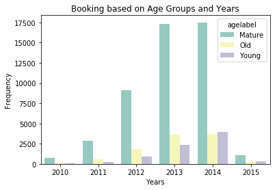

```python
sns.countplot(x="f1_year",hue="agelabel", data=users, palette="Set3", order=[2010,2011,2012,2013,2014,2015])
plt.xlabel('Years')
plt.ylabel('Frequency')
plt.title('Booking based on Age Groups and Years')
plt.show()
```

In 2014, the number of users in the age group "old" increases slightly.

It is time to analyze the features via book or not book.

```python
users['date_first_booking_tag']=users['date_first_booking'].fillna("No booking")

bookedornot = []

for i in users['date_first_booking_tag']:
    if i=="No booking":
        bookedornot.append('No booking')
    else:
        bookedornot.append('Booking')

users['bookedornot'] = bookedornot  #Creating a bookornot column from the list
```

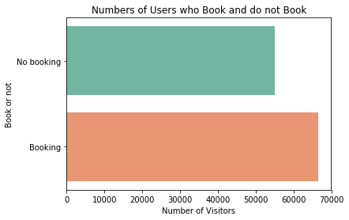

```python
sns.countplot(y='bookedornot', data=users,palette="Set2")
plt.ylabel('Book or not')
plt.xlabel('Number of Visitors')
plt.title('Numbers of Users who Book and do not Book')
plt.show()
```

```python
print("The number of users who do book is",
    users[users["bookedornot"] == "Booking"]["bookedornot"].count())

print("The number of users who do not book is",
    users[users["bookedornot"] == "No booking"]["bookedornot"].count())

print ("The average sign up flow of the users who do book is",
    users[users["bookedornot"] == "Booking"]["signup_flow"].mean())

print("The average sign up flow of the users who do not book is",
    users[users["bookedornot"] == "No booking"]["signup_flow"].mean())
```

```
The number of users who do book is 66571
The number of users who do not book is 55041
The average sign up flow of the users who do book is 2.455063015427138
The average sign up flow of the users who do not book is 2.642066822913828
```

It seems the average sign up flows of the users who books and do not book are close. However, it should be analyzed if there is a significant difference between them.

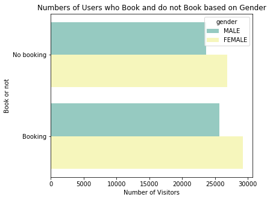

```python
plt.figure(figsize=(6,5))
sns.countplot(y='bookedornot', hue="gender", data=users,palette="Set3")
plt.ylabel('Book or not')
plt.xlabel('Number of Visitors')
plt.title('Numbers of Users who Book and do not Book based on Gender')
plt.show()
```

There are more female users than males who do not book just like for those who book.

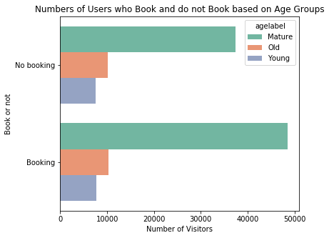

```python
plt.figure(figsize=(6,5))
sns.countplot(y='bookedornot', hue="agelabel", data=users,palette="Set2")
plt.ylabel('Book or not')
plt.xlabel('Number of Visitors')
plt.title('Numbers of Users who Book and do not Book based on Age Groups')
plt.show()
```

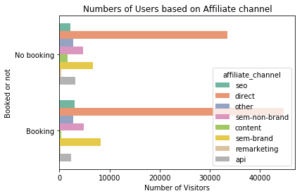

```python
sns.countplot(y='bookedornot', hue="affiliate_channel", data=users,palette="Set2")
plt.ylabel('Booked or not')
plt.xlabel('Number of Visitors')
plt.title('Numbers of Users based on Affiliate channel')
plt.show()
```

Most of the users come to Airbnb web page directly. Affiliate channel is a tool and way for [affiliate marketing](https://en.wikipedia.org/wiki/Affiliate_marketing). Users who books are come from affiliate_channel 'content' less than other channels.

## C. DISCUSSION & CONCLUSION

Year to year analyses show us that there are more users who booked in 2013 and 2014 than other years. The data does no cover whole year of 2015. It is easily seen that there is a rapid growth of users. It seems that more users who booked in April, May, and June than other months. Numbers of users increase at the beginning of the summer season.

Since the aim of the competition is to predict the future bookings, it better to use prediction models. Principal component analysis may be helpful to find out which features contribute to the prediction model more. For visualization, creating a funnel for the customer journey may be helpful to see the data from different sides and analyze the stages of customer experience.

## D. REFERENCES

[1] Airbnb New User Bookings. (2016). Retrieved from https://www.kaggle.com/c/airbnb-recruiting-new-user-bookings

[2] Airbnb. (2016). Retrieved from https://en.wikipedia.org/wiki/Airbnb